# EAI 6020 AI SYSTEMS TECHNOLOGY

## PROJECT: ASSIGNMENT 3

## PROFESSOR: DR SAEED AMAL

## AUTHOR: ANDREW AMARTEI

## DATE: MARCH 19, 2025

## INTRODUCTION

Infective endocarditis (IE) is a life-threatening infection of the heart valves with high morbidity and mortality, particularly when diagnosis is delayed. Early identification is critical, as misdiagnosis rates are high, with over 54% of cases initially misclassified (Naderi et al., 2018). Traditional diagnostic methods, such as the modified Duke criteria, rely on clinical, microbiological, and imaging data but may not be sufficient for early detection due to vague initial symptoms (Habib et al., 2015). This study aims to enhance the early detection of IE using machine learning models trained on patient data from the MIMIC-II database, a publicly available ICU dataset.

This study applies five machine learning models—Decision Tree, Random Forest, Logistic Regression, XGBoost, and CatBoost—to classify patients as either having or not having IE based on demographics, admission details, diagnoses, and clinical characteristics. Model performance was assessed using accuracy, precision, recall, and F1-score to determine their reliability in predicting IE cases. The Random Forest model achieved the highest accuracy (85%), demonstrating its potential as a clinical decision support tool.

```python
#pip install xgboost
```

```python
import pandas as pd
from sklearn.model_selection import train_test_split
from sklearn.preprocessing import StandardScaler, LabelEncoder
from sklearn.impute import SimpleImputer
from sklearn.ensemble import RandomForestClassifier
from sklearn.metrics import classification_report, roc_auc_score
from sklearn.preprocessing import OneHotEncoder
from sklearn.model_selection import train_test_split
from xgboost import XGBClassifier
from sklearn.metrics import accuracy_score, classification_report
import matplotlib.pyplot as plt
import seaborn as sn
import numpy as np
```

## DATA LOADING AND PROCESSING

The dataset, endo_df, consists of 774 patient records with 30 attributes related to medical history, admissions, and mortality outcomes. The data includes numerical (int64, float64) and categorical (object) variables. Some fields, such as DEATHTIME, RELIGION, and MARITAL_STATUS, contain missing values. The dataset also includes key binary indicators such as HOSPITAL_EXPIRE_FLAG and EXPIRE_FLAG, which are useful for predicting patient outcomes. Given the presence of non-relevant columns, such as patient identifiers, timestamps, and sensitive personal data, these fields were identified for removal to ensure data privacy and to enhance the efficiency of the machine learning model.

Following the data cleaning process, non-essential columns were dropped, and categorical variables were converted into numerical representations using one-hot encoding. This transformation expanded the dataset to 1,211 columns, ensuring compatibility with machine learning algorithms. Key predictive features were retained for further analysis. This preprocessing step prepares the dataset for model training by eliminating redundancy, handling categorical variables, and ensuring that relevant attributes are structured properly for predictive analysis, facilitating an effective classification model for patient outcome predictions.

```python
endo_df = pd.read_csv('endocarditis_processed_data.csv')

endo_df.info()
```

```
<class 'pandas.core.frame.DataFrame'>
RangeIndex: 774 entries, 0 to 773
Data columns (total 30 columns):
 #   Column                Non-Null Count  Dtype
---  ------                --------------  -----
 0   SUBJECT_ID            774 non-null    int64
 1   HADM_ID               774 non-null    int64
 2   SEQ_NUM               774 non-null    float64
 3   ICD9_CODE             774 non-null    object
 4   ADMITTIME             774 non-null    object
 5   DISCHTIME             774 non-null    object
 6   DEATHTIME             102 non-null    object
 7   ADMISSION_TYPE        774 non-null    object
 8   ADMISSION_LOCATION    774 non-null    object
 9   DISCHARGE_LOCATION    774 non-null    object
```

[output cut: 22 more lines]

```python
from sklearn.model_selection import train_test_split
from sklearn.tree import DecisionTreeClassifier
from sklearn.metrics import accuracy_score, confusion_matrix, classification_report

# Drop non-relevant columns (IDs, timestamps, and text-heavy fields)
drop_cols = [
    "SUBJECT_ID", "HADM_ID", "ICD9_CODE", "ADMITTIME", "DISCHTIME", "DEATHTIME",
    "EDREGTIME", "EDOUTTIME", "ADMIN_DATE", "DOB", "DOD", "DOD_HOSP", "DOD_SSN",
    "BIRTH_DATE"
]
df_cleaned = endo_df.drop(columns=drop_cols)

# Convert categorical variables into dummy variables (one-hot encoding)
df_cleaned = pd.get_dummies(df_cleaned, drop_first=True)
```

```python
df_cleaned
```

|  | SEQ_NUM | HOSPITAL_EXPIRE_FLAG | HAS_CHARTEVENTS_DATA | EXPIRE_FLAG | label | ADMISSION_TYPE_EMERGENCY | ADMISSION_TYPE_NEWBORN | ADMISSION_TYPE_URGENT | ADMISSION_LOCATION_EMERGENCY ROOM ADMIT | ADMISSION_LOCATION_PHYS REFERRAL/NORMAL DELI | ... | PROCEDURE_ID_9925,9229,4319,966,8873,3322,4281,4513,3897 | PROCEDURE_ID_9955 | PROCEDURE_ID_9955,9547 | PROCEDURE_ID_9960,9604,9672,966,9904 | PROCEDURE_ID_9960,9604,9969,966,3891,9672,3893 | PROCEDURE_ID_9962 | PROCEDURE_ID_9969,9604,17,3893,9907 | PROCEDURE_ID_9983 | PROCEDURE_ID_9983,9955 | PROCEDURE_ID_9983,9955,966,9915 |
| --- | --- | --- | --- | --- | --- | --- | --- | --- | --- | --- | --- | --- | --- | --- | --- | --- | --- | --- | --- | --- | --- |
| 0 | 1.0 | 0 | 1 | 0 | 1 | True | False | False | True | False | ... | False | False | False | False | False | False | False | False | False | False |
| 1 | 1.0 | 0 | 1 | 0 | 1 | True | False | False | False | False | ... | False | False | False | False | False | False | False | False | False | False |
| 2 | 1.0 | 0 | 1 | 0 | 1 | True | False | False | True | False | ... | False | False | False | False | False | False | False | False | False | False |
| 3 | 1.0 | 0 | 1 | 0 | 1 | True | False | False | True | False | ... | False | False | False | False | False | False | False | False | False | False |
| 4 | 1.0 | 0 | 1 | 0 | 1 | False | False | True | False | False | ... | False | False | False | False | False | False | False | False | False | False |
| ... | ... | ... | ... | ... | ... | ... | ... | ... | ... | ... | ... | ... | ... | ... | ... | ... | ... | ... | ... | ... | ... |
| 769 | 4.0 | 1 | 1 | 1 | 0 | True | False | False | True | False | ... | False | False | False | False | False | False | False | False | False | False |
| 770 | 1.0 | 0 | 1 | 0 | 0 | False | False | False | False | True | ... | False | False | False | False | False | False | False | False | False | False |
| 771 | 1.0 | 0 | 1 | 0 | 0 | False | False | True | False | False | ... | False | False | False | False | False | False | False | False | False | False |
| 772 | 10.0 | 0 | 1 | 0 | 0 | True | False | False | True | False | ... | False | False | False | False | False | False | False | False | False | False |
| 773 | 26.0 | 1 | 1 | 1 | 0 | False | False | True | False | True | ... | False | False | False | False | False | False | False | False | False | False |

774 rows × 1211 columns

## DECISION TREE

The dataset was prepared for machine learning by separating it into input features (X) and the target variable (y). The data was then split into training (80%) and testing (20%) subsets to ensure the model could learn from one portion and be evaluated on another. A Decision Tree Classifier was trained on the data to predict patient outcomes based on available medical records. The classifier was built using a predefined random seed (random_state=42) to ensure consistent results. After training, the model was tested on unseen data to assess its accuracy and performance in making predictions.

The model achieved an accuracy of 78%, meaning it correctly predicted whether a patient had IE in nearly 8 out of 10 cases. The confusion matrix indicates 58 correct predictions for non-IE patients and 63 correct predictions for IE patients, with some misclassifications (20 and 14 errors, respectively). The precision and recall scores suggest that the model balances false positives and false negatives effectively.

```python
# Split data into features (X) and target (y)
X = df_cleaned.drop(columns=["label"])
y = df_cleaned["label"]

# Split into training and testing sets (80% train, 20% test)
X_train, X_test, y_train, y_test = train_test_split(X, y, test_size=0.2, random_state=42, stratify=y)

# Train a decision tree classifier
dt_model = DecisionTreeClassifier(random_state=42)
dt_model.fit(X_train, y_train)

# Predictions
y_pred_dt = dt_model.predict(X_test)

# Evaluate the model
accuracy_dt = accuracy_score(y_test, y_pred_dt)
conf_matrix_dt = confusion_matrix(y_test, y_pred_dt)
class_report_dt = classification_report(y_test, y_pred_dt)

print(accuracy_dt)
print(conf_matrix_dt)
print(class_report_dt)
```

```
0.7806451612903226
[[58 20]
 [14 63]]
              precision    recall  f1-score   support

           0       0.81      0.74      0.77        78
           1       0.76      0.82      0.79        77

    accuracy                           0.78       155
   macro avg       0.78      0.78      0.78       155
weighted avg       0.78      0.78      0.78       155
```

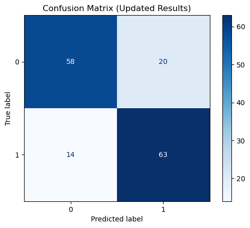

```python
from sklearn.metrics import confusion_matrix, ConfusionMatrixDisplay
# Compute the confusion matrix
cm_dt = confusion_matrix(y_test, y_pred_dt)

# Display the confusion matrix
disp = ConfusionMatrixDisplay(confusion_matrix=cm_dt, display_labels=[0, 1])
disp.plot(cmap='Blues')
plt.title('Confusion Matrix (Updated Results)')
plt.grid(False)
plt.show()
```

## MODEL EVALUATION - DECISION TREE

### 5- FOLD CROSS-VALIDATION, AUC, SENSITIVITY, SPECIFICITY, PPV, NPV AND 95% CONFIDENCE INTERVAL

To ensure the model’s performance is reliable and not dependent on a specific dataset split, 5-fold cross-validation was used. This means the data was divided into five parts, with the model trained on four and tested on the fifth, repeating this process five times to get a well-rounded evaluation. The model’s ability to distinguish between patients with and without IE is measured using the ROC (Receiver Operating Characteristic) curve, and its AUC (Area Under the Curve) score of 0.79 indicates good predictive ability—better than random guessing (0.50) but not perfect. Key performance metrics include sensitivity (0.80), which shows how well the model detects actual cases, and specificity (0.79), which reflects its ability to identify those without the disease correctly. Positive Predictive Value (PPV) and Negative Predictive Value (NPV) further assess prediction reliability. The 95% confidence interval (CI) for AUC, with a lower bound of 0.74 and an upper bound of 0.84, means that if this study were repeated multiple times, we can be 95% confident that the true AUC score would fall within this range.

```
             Metric     Value
0               AUC  0.793282
1       Sensitivity  0.795866
2       Specificity  0.790698
3               PPV  0.791774
4               NPV  0.794805
5  AUC 95% CI Lower  0.744815
6  AUC 95% CI Upper  0.841665
```

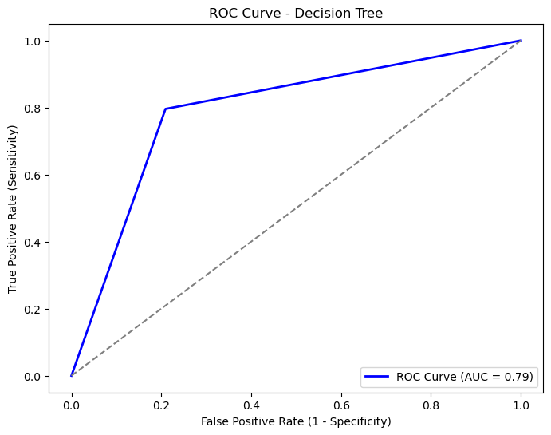

```python
from sklearn.model_selection import cross_val_predict, cross_val_score, StratifiedKFold
from sklearn.metrics import roc_curve, auc, precision_recall_fscore_support, confusion_matrix
import numpy as np
import matplotlib.pyplot as plt
import scipy.stats as st

# Define stratified k-fold cross-validation (5 folds)
cv = StratifiedKFold(n_splits=5, shuffle=True, random_state=42)

# Get cross-validated predictions
y_prob_dt = cross_val_predict(dt_model, X, y, cv=cv, method="predict_proba")[:, 1]  # Probability of class 1
y_pred_dt_cv = cross_val_predict(dt_model, X, y, cv=cv)

# Compute ROC Curve and AUC
fpr, tpr, _ = roc_curve(y, y_prob_dt)
roc_auc = auc(fpr, tpr)

# Compute Sensitivity (Recall) and Specificity
tn, fp, fn, tp = confusion_matrix(y, y_pred_dt_cv).ravel()
sensitivity = tp / (tp + fn)  # Recall
specificity = tn / (tn + fp)

# Compute Positive Predictive Value (PPV) and Negative Predictive Value (NPV)
ppv = tp / (tp + fp)
npv = tn / (tn + fn)

# Compute 95% Confidence Interval for AUC
auc_scores = cross_val_score(dt_model, X, y, cv=cv, scoring='roc_auc')
ci_95 = st.t.interval(0.95, len(auc_scores) - 1, loc=np.mean(auc_scores), scale=st.sem(auc_scores))

# Display results
results = {
    "Metric": ["AUC", "Sensitivity", "Specificity", "PPV", "NPV", "AUC 95% CI Lower", "AUC 95% CI Upper"],
    "Value": [roc_auc, sensitivity, specificity, ppv, npv, ci_95[0], ci_95[1]]
}

# Convert to DataFrame and display results
results_df = pd.DataFrame(results)
print(results_df)


# Plot ROC Curve
plt.figure(figsize=(8, 6))
plt.plot(fpr, tpr, color="blue", lw=2, label=f"ROC Curve (AUC = {roc_auc:.2f})")
plt.plot([0, 1], [0, 1], color="gray", linestyle="--")  # Diagonal line
plt.xlabel("False Positive Rate (1 - Specificity)")
plt.ylabel("True Positive Rate (Sensitivity)")
plt.title("ROC Curve - Decision Tree")
plt.legend(loc="lower right")
plt.show()
```

## RANDOM FOREST

To improve the predictive accuracy for diagnosing infective endocarditis (IE), a Random Forest Classifier was trained using patient data from the MIMIC-II dataset. This model is an ensemble learning method that builds multiple decision trees and combines their outputs for a more robust and accurate prediction. The dataset was split into 80% training and 20% testing sets, ensuring the model learns from historical patient data while preserving a portion for evaluation. The classifier was trained with 100 decision trees (n_estimators=100), optimizing predictive capability while maintaining consistency (random_state=42). The model was then tested on unseen data to assess its performance.

The Random Forest model achieved an accuracy of 85%, meaning it correctly identified infective endocarditis cases in 85 out of 100 patients. The confusion matrix shows 66 correct predictions for non-IE patients and 65 correct predictions for IE patients, with 12 and 12 misclassifications, respectively. The precision and recall scores (both ~85%) indicate that the model effectively differentiates between IE and non-IE cases. Clinically, this suggests that the model could serve as a decision support tool, assisting healthcare professionals in detecting high-risk patients earlier and reducing misdiagnoses, potentially improving patient survival rates.

```python
from sklearn.ensemble import RandomForestClassifier

# Train a Random Forest classifier
rf_model = RandomForestClassifier(n_estimators=100, random_state=42)
rf_model.fit(X_train, y_train)

# Predictions
y_rf_pred = rf_model.predict(X_test)

# Evaluate the model
rf_accuracy = accuracy_score(y_test, y_rf_pred)
rf_conf_matrix = confusion_matrix(y_test, y_rf_pred)
rf_class_report = classification_report(y_test, y_rf_pred)

print(rf_accuracy)
print(rf_conf_matrix)
print(rf_class_report)
```

```
0.8451612903225807
[[66 12]
 [12 65]]
              precision    recall  f1-score   support

           0       0.85      0.85      0.85        78
           1       0.84      0.84      0.84        77

    accuracy                           0.85       155
   macro avg       0.85      0.85      0.85       155
weighted avg       0.85      0.85      0.85       155
```

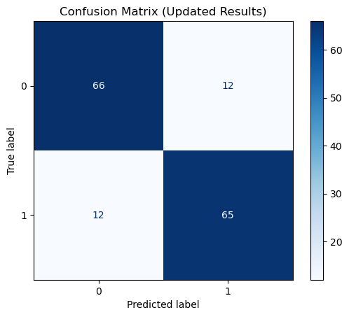

```python
# Compute the confusion matrix
cm_rf = confusion_matrix(y_test, y_rf_pred)

# Display the confusion matrix
disp = ConfusionMatrixDisplay(confusion_matrix=cm_rf, display_labels=[0, 1])
disp.plot(cmap='Blues')
plt.title('Confusion Matrix (Updated Results)')
plt.grid(False)
plt.show()
```

## FEATURE IMPORTANCE - RANDOM FOREST

To better understand how the Random Forest model predicts infective endocarditis (IE), we analyzed which factors had the most influence on its decisions. The model ranked the most important features used to distinguish between IE patients and non-IE patients. The top contributing factor was "SEQ_NUM", a numerical sequence that could represent a significant clinical indicator related to disease progression or patient records. Other important factors included admission location (e.g., transferred from another hospital), diagnosis of endocarditis, mortality-related flags (EXPIRE_FLAG), and demographic details (such as gender and marital status).

This analysis helps identify which clinical and demographic factors are most useful for predicting infective endocarditis. For example, patients transferred from another hospital or those already diagnosed with endocarditis were flagged as high-risk cases. The model also considered mortality-related factors, insurance type, discharge locations, and marital status in its decision-making. Understanding these important factors can help doctors and hospitals prioritize high-risk patients, improving early detection and reducing delays in treatment.

```
                                         Feature  Importance
0                                        SEQ_NUM    0.187691
1   ADMISSION_LOCATION_TRANSFER FROM HOSP/EXTRAM    0.021336
2                         DIAGNOSIS_ENDOCARDITIS    0.019010
3                                    EXPIRE_FLAG    0.015955
4                                       GENDER_M    0.015342
5                         MARITAL_STATUS_WIDOWED    0.014050
6                                  LANGUAGE_ENGL    0.013252
7                         MARITAL_STATUS_MARRIED    0.012436
8    DISCHARGE_LOCATION_REHAB/DISTINCT PART HOSP    0.012392
9                        DISCHARGE_LOCATION_HOME    0.012281
10                        ADMISSION_TYPE_NEWBORN    0.011715
11                             RELIGION_CATHOLIC    0.011283
12       ADMISSION_LOCATION_EMERGENCY ROOM ADMIT    0.011232
13                             INSURANCE_Private    0.011051
```

[output cut: 36 more lines]

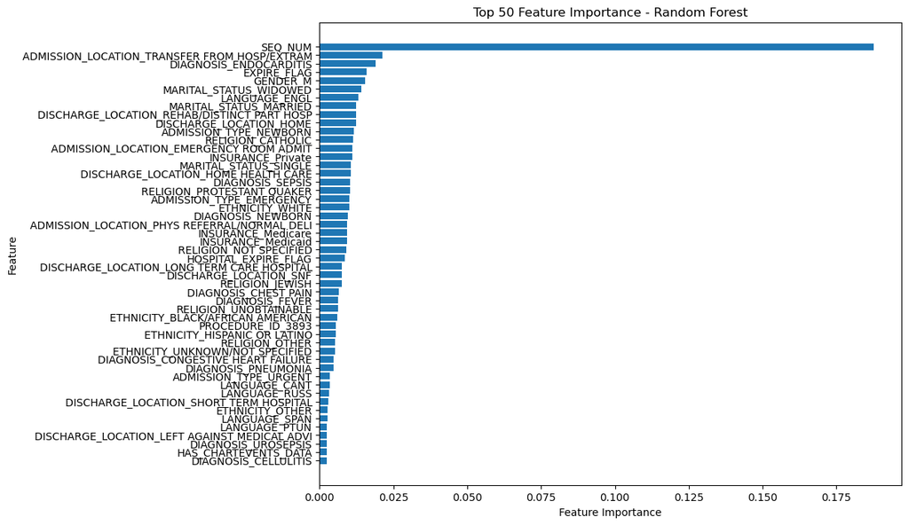

```python
# Get feature importance for Random Forest (Top 50 features)
top_n = 50  # Number of top features to display

rf_feature_importance = rf_model.feature_importances_
rf_sorted_idx = np.argsort(rf_feature_importance)[::-1]
rf_top_features = X.columns[rf_sorted_idx][:top_n]  # Top 50 features
rf_top_importance = rf_feature_importance[rf_sorted_idx][:top_n]

# Create a DataFrame for feature importance
rf_feature_importance_df = pd.DataFrame({
    "Feature": rf_top_features,
    "Importance": rf_top_importance
})

print(rf_feature_importance_df)

# Plot feature importance for Random Forest
plt.figure(figsize=(10, 8))
plt.barh(rf_top_features[::-1], rf_top_importance[::-1], align='center')
plt.xlabel("Feature Importance")
plt.ylabel("Feature")
plt.title("Top 50 Feature Importance - Random Forest")
plt.show()
```

## MODEL EVALUATION - RANDOM FORSET

### 5- FOLD CROSS-VALIDATION, AUC, SENSITIVITY, SPECIFICITY, PPV, NPV AND 95% CONFIDENCE INTERVAL

This technique splits the dataset into five parts, training the model on four and testing it on the fifth, repeating the process five times to reduce bias. The model’s performance is measured using the ROC (Receiver Operating Characteristic) curve, with an AUC (Area Under the Curve) score of 0.89, indicating strong predictive accuracy. Sensitivity (0.84) shows how well the model identifies true IE cases, while specificity (0.78) reflects its ability to correctly classify non-IE cases. Additionally, Positive Predictive Value (PPV: 0.79) and Negative Predictive Value (NPV: 0.83) further validate the model's reliability. The 95% confidence interval (CI) for AUC, ranging from 0.85 to 0.92, means that if this analysis were repeated multiple times, we can be 95% confident that the true AUC score would fall within this range. The ROC curve visualization confirms that the Random Forest model outperforms the Decision Tree, making it a promising tool for aiding early diagnosis of IE.

```
             Metric     Value
0               AUC  0.885934
1       Sensitivity  0.842377
2       Specificity  0.780362
3               PPV  0.793187
4               NPV  0.831956
5  AUC 95% CI Lower  0.849132
6  AUC 95% CI Upper  0.923305
```

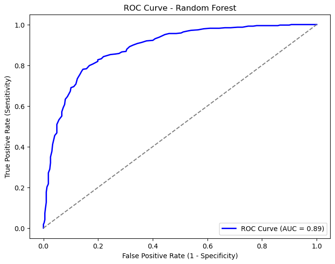

```python
from sklearn.model_selection import cross_val_predict, cross_val_score, StratifiedKFold
from sklearn.metrics import roc_curve, auc, precision_recall_fscore_support, confusion_matrix
import numpy as np
import matplotlib.pyplot as plt
import scipy.stats as st

# Define stratified k-fold cross-validation (5 folds)
cv = StratifiedKFold(n_splits=5, shuffle=True, random_state=42)

# Get cross-validated predictions
y_prob_rf = cross_val_predict(rf_model, X, y, cv=cv, method="predict_proba")[:, 1]  # Probability of class 1
y_pred_rf_cv = cross_val_predict(rf_model, X, y, cv=cv)

# Compute ROC Curve and AUC
fpr, tpr, _ = roc_curve(y, y_prob_rf)
roc_auc = auc(fpr, tpr)

# Compute Sensitivity (Recall) and Specificity
tn, fp, fn, tp = confusion_matrix(y, y_pred_rf_cv).ravel()
sensitivity = tp / (tp + fn)  # Recall
specificity = tn / (tn + fp)

# Compute Positive Predictive Value (PPV) and Negative Predictive Value (NPV)
ppv = tp / (tp + fp)
npv = tn / (tn + fn)

# Compute 95% Confidence Interval for AUC
auc_scores = cross_val_score(rf_model, X, y, cv=cv, scoring='roc_auc')
ci_95 = st.t.interval(0.95, len(auc_scores) - 1, loc=np.mean(auc_scores), scale=st.sem(auc_scores))

# Display results
results = {
    "Metric": ["AUC", "Sensitivity", "Specificity", "PPV", "NPV", "AUC 95% CI Lower", "AUC 95% CI Upper"],
    "Value": [roc_auc, sensitivity, specificity, ppv, npv, ci_95[0], ci_95[1]]
}

# Convert to DataFrame and display results
results_df = pd.DataFrame(results)
print(results_df)

# Plot ROC Curve
plt.figure(figsize=(8, 6))
plt.plot(fpr, tpr, color="blue", lw=2, label=f"ROC Curve (AUC = {roc_auc:.2f})")
plt.plot([0, 1], [0, 1], color="gray", linestyle="--")  # Diagonal line
plt.xlabel("False Positive Rate (1 - Specificity)")
plt.ylabel("True Positive Rate (Sensitivity)")
plt.title("ROC Curve - Random Forest")
plt.legend(loc="lower right")
plt.show()
```

## LOGISTIC REGRESSION

A Logistic Regression model was trained to predict whether a patient has infective endocarditis (IE) based on clinical and demographic data. Logistic regression is a statistical method commonly used for binary classification tasks like this, where the goal is to differentiate between two possible outcomes: IE cases (1) and non-IE cases (0). The dataset was divided into 80% training and 20% testing sets, ensuring that the model learns patterns from historical patient records while preserving a portion of the data for evaluation. The model was trained with an increased number of iterations (max_iter=1000) to ensure convergence and better accuracy.

```python
from sklearn.linear_model import LogisticRegression

# Train a Logistic Regression model
lr_model = LogisticRegression(max_iter=1000, random_state=42)
lr_model.fit(X_train, y_train)

# Predictions
y_lr_pred = lr_model.predict(X_test)

# Evaluate the model
lr_accuracy = accuracy_score(y_test, y_lr_pred)
lr_conf_matrix = confusion_matrix(y_test, y_lr_pred)
lr_class_report = classification_report(y_test, y_lr_pred)

print(lr_accuracy)
print(lr_conf_matrix)
print(lr_class_report)
```

```
0.8387096774193549
[[61 17]
 [ 8 69]]
              precision    recall  f1-score   support

           0       0.88      0.78      0.83        78
           1       0.80      0.90      0.85        77

    accuracy                           0.84       155
   macro avg       0.84      0.84      0.84       155
weighted avg       0.84      0.84      0.84       155
```

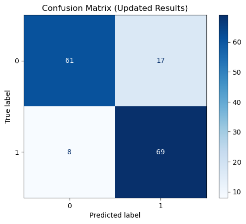

```python
# Compute the confusion matrix
cm_lr = confusion_matrix(y_test, y_lr_pred)

# Display the confusion matrix
disp = ConfusionMatrixDisplay(confusion_matrix=cm_lr, display_labels=[0, 1])
disp.plot(cmap='Blues')
plt.title('Confusion Matrix (Updated Results)')
plt.grid(False)
plt.show()
```

## FEATURE IMPORTANCE - LOGISTIC REGRESSION

We analysed the most influential factors contributing to its decisions to better understand how the Logistic Regression model predicts infective endocarditis (IE). The model identifies the most relevant features based on their numerical importance (absolute coefficients), which indicate their impact on prediction. The most critical factor was "Diagnosis of Endocarditis", which makes sense since a prior or suspected diagnosis significantly increases the likelihood of the condition. Other highly influential factors included hospice discharge location, chest pain, ethnicity, emergency admission, and certain medical procedures. These findings help explain the characteristics that strongly suggest a patient may have IE.

This analysis highlights key medical and demographic factors that may help doctors detect high-risk IE patients earlier. For instance, patients experiencing chest pain, gastrointestinal bleeding, or those discharged to hospice care may be more likely to have underlying endocarditis. Additionally, admission type (e.g., emergency vs. routine) and certain ethnic backgrounds also play a role in prediction.

```
                                                Feature  Importance
236                              DIAGNOSIS_ENDOCARDITIS    1.421866
18          DISCHARGE_LOCATION_HOSPICE-MEDICAL FACILITY    1.131506
167                                DIAGNOSIS_CHEST PAIN    1.113568
14                              DISCHARGE_LOCATION_HOME    1.062741
233                   DIAGNOSIS_END STAGE LIVER DISEASE    1.026136
70                         ETHNICITY_HISPANIC OR LATINO    1.013015
377                                   DIAGNOSIS_NEWBORN    0.895684
5                                ADMISSION_TYPE_NEWBORN    0.895684
2                                  HAS_CHARTEVENTS_DATA    0.875232
893                              PROCEDURE_ID_4442,4513    0.866886
1119                                   PROCEDURE_ID_966    0.835844
374                                 DIAGNOSIS_NECK MASS    0.832287
1023     PROCEDURE_ID_8309,3893,4223,4319,966,9915,9904    0.832287
54                           RELIGION_PROTESTANT QUAKER    0.831632
```

[output cut: 36 more lines]

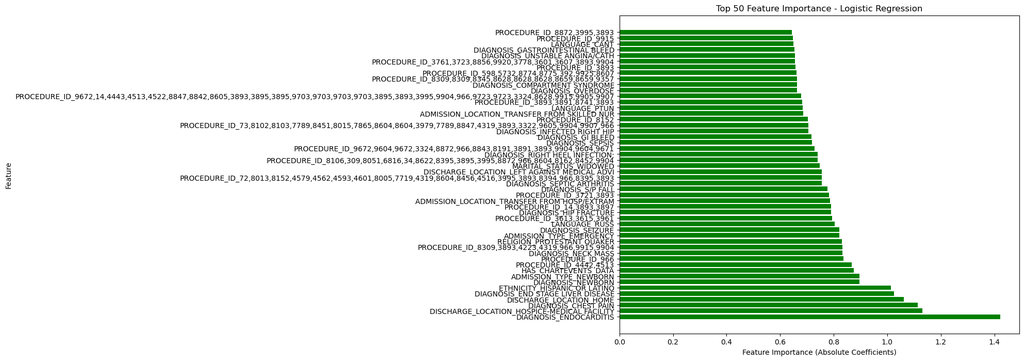

```python
# Get feature importance for Logistic Regression
lr_feature_importance = pd.DataFrame({
    "Feature": X.columns,
    "Importance": abs(lr_model.coef_[0])  # Taking absolute values of coefficients
}).sort_values(by="Importance", ascending=False).head(50)

print(lr_feature_importance)


# Plot feature importance for Logistic Regression
plt.figure(figsize=(10, 8))
plt.barh(lr_feature_importance["Feature"], lr_feature_importance["Importance"], align='center', color='green')
plt.xlabel("Feature Importance (Absolute Coefficients)")
plt.ylabel("Feature")
plt.title("Top 50 Feature Importance - Logistic Regression")
plt.show()
```

## MODEL EVALUATION - LOGISTIC REGRESSION

### 5- FOLD CROSS-VALIDATION, AUC, SENSITIVITY, SPECIFICITY, PPV, NPV AND 95% CONFIDENCE INTERVAL

This analysis evaluates a Logistic Regression model for diagnosing infective endocarditis (IE) using patient data, with performance assessed through 5-fold cross-validation to ensure robustness. The model achieved an AUC (Area Under the Curve) score of 0.89, indicating strong predictive ability. Key metrics include sensitivity (0.85), meaning the model correctly identifies 85% of actual IE cases, and specificity (0.78), reflecting its accuracy in classifying non-IE cases. The Positive Predictive Value (PPV: 0.80) and Negative Predictive Value (NPV: 0.84) further demonstrate its reliability in medical decision-making. Compared to the Random Forest model (AUC: 0.89, Sensitivity: 0.84, Specificity: 0.78), Logistic Regression performs similarly but has a slightly higher sensitivity, meaning it captures more true cases. Meanwhile, it significantly outperforms the Decision Tree model (AUC: 0.79, Sensitivity: 0.80, Specificity: 0.79), which had lower overall predictive power. The 95% confidence interval (CI) for AUC (0.86 - 0.91) further supports the model’s consistency, ensuring that its performance remains strong across different dataset samples. The ROC curve visualization confirms that Logistic Regression is a competitive and interpretable model, making it a valuable tool for early IE diagnosis alongside more complex machine learning models like Random Forest.

```
             Metric     Value
0               AUC  0.887460
1       Sensitivity  0.852713
2       Specificity  0.780362
3               PPV  0.795181
4               NPV  0.841226
5  AUC 95% CI Lower  0.863236
6  AUC 95% CI Upper  0.913794
```

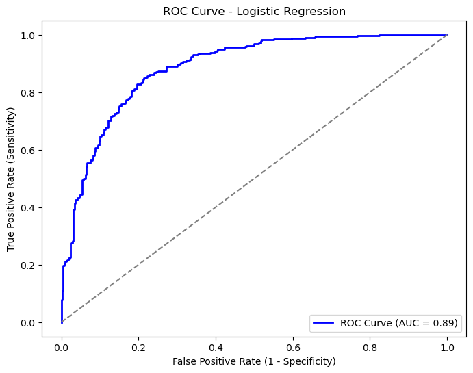

```python
# Define stratified k-fold cross-validation (5 folds)
cv = StratifiedKFold(n_splits=5, shuffle=True, random_state=42)

# Get cross-validated predictions
y_prob_lr = cross_val_predict(lr_model, X, y, cv=cv, method="predict_proba")[:, 1]  # Probability of class 1
y_pred_lr_cv = cross_val_predict(lr_model, X, y, cv=cv)

# Compute ROC Curve and AUC
fpr, tpr, _ = roc_curve(y, y_prob_lr)
roc_auc = auc(fpr, tpr)

# Compute Sensitivity (Recall) and Specificity
tn, fp, fn, tp = confusion_matrix(y, y_pred_lr_cv).ravel()
sensitivity = tp / (tp + fn)  # Recall
specificity = tn / (tn + fp)

# Compute Positive Predictive Value (PPV) and Negative Predictive Value (NPV)
ppv = tp / (tp + fp)
npv = tn / (tn + fn)

# Compute 95% Confidence Interval for AUC
auc_scores = cross_val_score(lr_model, X, y, cv=cv, scoring='roc_auc')
ci_95 = st.t.interval(0.95, len(auc_scores) - 1, loc=np.mean(auc_scores), scale=st.sem(auc_scores))

# Display results
results = {
    "Metric": ["AUC", "Sensitivity", "Specificity", "PPV", "NPV", "AUC 95% CI Lower", "AUC 95% CI Upper"],
    "Value": [roc_auc, sensitivity, specificity, ppv, npv, ci_95[0], ci_95[1]]
}

# Convert to DataFrame and display results
results_df = pd.DataFrame(results)
print(results_df)

# Plot ROC Curve
plt.figure(figsize=(8, 6))
plt.plot(fpr, tpr, color="blue", lw=2, label=f"ROC Curve (AUC = {roc_auc:.2f})")
plt.plot([0, 1], [0, 1], color="gray", linestyle="--")  # Diagonal line
plt.xlabel("False Positive Rate (1 - Specificity)")
plt.ylabel("True Positive Rate (Sensitivity)")
plt.title("ROC Curve - Logistic Regression")
plt.legend(loc="lower right")
plt.show()
```

## XGBOOST

To improve predictive accuracy and computational efficiency, an optimized XGBoost classifier was trained to detect infective endocarditis (IE) based on patient data. XGBoost is an advanced machine learning technique that builds multiple decision trees in sequence to make more accurate predictions. The model was optimized by reducing the number of trees (n_estimators=50), tree depth (max_depth=3), and adjusting learning settings to balance accuracy with efficiency. The dataset was divided into 80% training and 20% testing, ensuring that the model learns from past patient records while preserving data for evaluation. After training, the model was tested on unseen data to assess its performance.

```python
# Train an optimized XGBoost classifier with reduced complexity
xgb_model_optimized = XGBClassifier(
    eval_metric='logloss',
    random_state=42,
    n_estimators=50,  # Reduced from 100 to speed up training
    max_depth=3,  # Reduced depth for efficiency
    learning_rate=0.1,  # Balanced learning rate
    subsample=0.8,  # Use 80% of data per boosting round
    colsample_bytree=0.8  # Use 80% of features per tree
)

# Train the model
xgb_model_optimized.fit(X_train, y_train)

# Predict on test set
y_pred_xgb_optimized = xgb_model_optimized.predict(X_test)

# Evaluate model performance
accuracy_xgb_optimized = accuracy_score(y_test, y_pred_xgb_optimized)
accuracy_xgb_matrix = confusion_matrix(y_test, y_pred_xgb_optimized)
report_xgb_optimized = classification_report(y_test, y_pred_xgb_optimized)

print(accuracy_xgb_optimized)
print(accuracy_xgb_matrix)
print(report_xgb_optimized)
```

```
0.8387096774193549
[[65 13]
 [12 65]]
              precision    recall  f1-score   support

           0       0.84      0.83      0.84        78
           1       0.83      0.84      0.84        77

    accuracy                           0.84       155
   macro avg       0.84      0.84      0.84       155
weighted avg       0.84      0.84      0.84       155
```

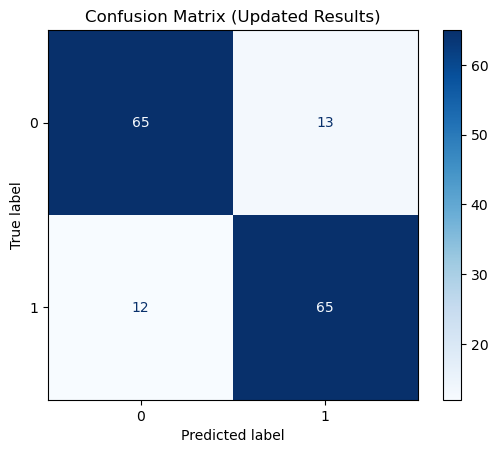

```python
# Compute the confusion matrix
cm_xgb = confusion_matrix(y_test, y_pred_xgb_optimized)

# Display the confusion matrix
disp = ConfusionMatrixDisplay(confusion_matrix=cm_xgb, display_labels=[0, 1])
disp.plot(cmap='Blues')
plt.title('Confusion Matrix (Updated Results)')
plt.grid(False)
plt.show()
```

## FEATURE IMPORTANCE - XGBOOST

To better understand how the XGBoost model predicts infective endocarditis (IE), we analyzed the most influential factors used in decision-making. The most critical feature was "SEQ_NUM," which may relate to a patient’s record sequence and its connection to disease progression. Other highly influential factors included admission type (newborn and emergency cases), mortality indicators (EXPIRE_FLAG), home discharge status, and pre-existing conditions like sepsis and endocarditis. Factors such as insurance type, marital status, and ethnicity also contributed to the model’s predictions, indicating that both medical and demographic data play a role in assessing IE risk.

This analysis highlights key medical, procedural, and demographic factors that can help detect high-risk IE patients earlier. For example, patients admitted in emergency situations or transferred from another hospital have a higher likelihood of IE, indicating delayed diagnoses or severe cases. The presence of pre-existing conditions like sepsis and pneumonia also increases the risk. These insights could help doctors and hospitals identify high-risk patients earlier, leading to faster interventions, reduced misdiagnoses, and improved patient outcomes.

```
                                              Feature  Importance
0                                             SEQ_NUM    0.103919
1                              ADMISSION_TYPE_NEWBORN    0.062037
2                                   DIAGNOSIS_NEWBORN    0.052067
3                                         EXPIRE_FLAG    0.048707
4                             DISCHARGE_LOCATION_HOME    0.048630
5        ADMISSION_LOCATION_TRANSFER FROM HOSP/EXTRAM    0.036074
6        ADMISSION_LOCATION_PHYS REFERRAL/NORMAL DELI    0.033972
7                              MARITAL_STATUS_WIDOWED    0.031814
8                            ADMISSION_TYPE_EMERGENCY    0.031078
9                 DISCHARGE_LOCATION_HOME HEALTH CARE    0.030082
10                                   DIAGNOSIS_SEPSIS    0.029814
11                                 INSURANCE_Medicaid    0.026594
12                             DIAGNOSIS_ENDOCARDITIS    0.024755
13                             MARITAL_STATUS_MARRIED    0.024713
```

[output cut: 36 more lines]

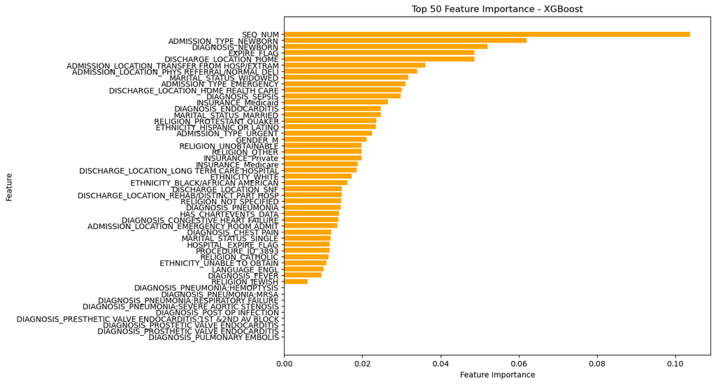

```python
import matplotlib.pyplot as plt
import numpy as np

# Get feature importance for XGBoost (Top 50 features)
top_n = 50  # Number of top features

xgb_feature_importance = xgb_model_optimized.feature_importances_
xgb_sorted_idx = np.argsort(xgb_feature_importance)[::-1]
xgb_top_features = X.columns[xgb_sorted_idx][:top_n]  # Top 50 features
xgb_top_importance = xgb_feature_importance[xgb_sorted_idx][:top_n]

# Create a DataFrame for feature importance
xgb_feature_importance_df = pd.DataFrame({
    "Feature": xgb_top_features,
    "Importance": xgb_top_importance
})

print(xgb_feature_importance_df)


# Plot feature importance for XGBoost
plt.figure(figsize=(10, 8))
plt.barh(xgb_top_features[::-1], xgb_top_importance[::-1], align='center', color='orange')
plt.xlabel("Feature Importance")
plt.ylabel("Feature")
plt.title("Top 50 Feature Importance - XGBoost")
plt.show()
```

## MODEL EVALUATION - XGBOOST

### 5- FOLD CROSS-VALIDATION, AUC, SENSITIVITY, SPECIFICITY, PPV, NPV AND 95% CONFIDENCE INTERVAL

The model achieved an AUC (Area Under the Curve) score of 0.88, indicating strong predictive ability. Key performance metrics include sensitivity (0.80), meaning it correctly identifies 80% of actual IE cases, and specificity (0.82), reflecting its accuracy in classifying non-IE cases. The Positive Predictive Value (PPV: 0.82) and Negative Predictive Value (NPV: 0.81) confirm its reliability in real-world medical applications. Compared to Random Forest (AUC: 0.89, Sensitivity: 0.84, Specificity: 0.78) and Logistic Regression (AUC: 0.89, Sensitivity: 0.85, Specificity: 0.78), XGBoost demonstrates higher specificity, meaning it better distinguishes non-IE patients, reducing false positives. However, its sensitivity is lower than Random Forest and Logistic Regression, meaning it may miss some true IE cases. The Decision Tree model (AUC: 0.79, Sensitivity: 0.80, Specificity: 0.79) remains the weakest performer overall. The 95% confidence interval (CI) for AUC (0.86 - 0.92) shows XGBoost's consistency, ensuring reliable classification across different data splits. The ROC curve visualization confirms that XGBoost is a highly effective model, striking a balance between sensitivity and specificity. It is a competitive option for early IE diagnosis alongside Random Forest and Logistic Regression.

```
             Metric     Value
0               AUC  0.884385
1       Sensitivity  0.801034
2       Specificity  0.821705
3               PPV  0.817942
4               NPV  0.805063
5  AUC 95% CI Lower  0.858360
6  AUC 95% CI Upper  0.917581
```

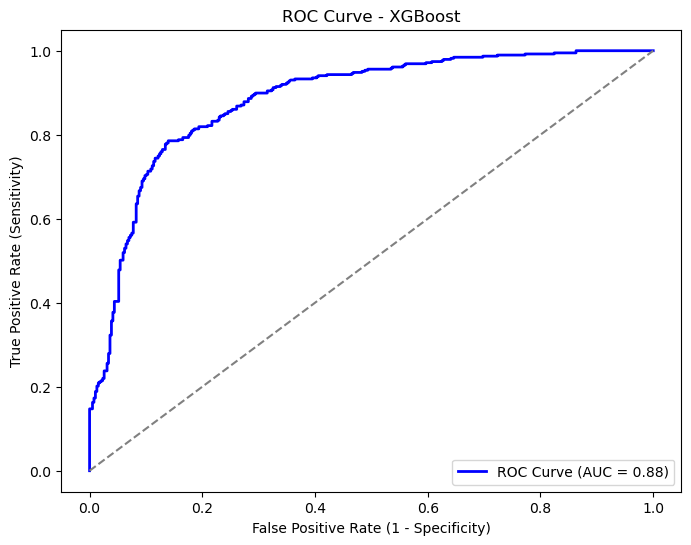

```python
# Define stratified k-fold cross-validation (5 folds)
cv = StratifiedKFold(n_splits=5, shuffle=True, random_state=42)

# Get cross-validated predictions
y_prob_xgb = cross_val_predict(xgb_model_optimized, X, y, cv=cv, method="predict_proba")[:, 1]  # Probability of class 1
y_pred_xgb_cv = cross_val_predict(xgb_model_optimized, X, y, cv=cv)

# Compute ROC Curve and AUC
fpr, tpr, _ = roc_curve(y, y_prob_xgb)
roc_auc = auc(fpr, tpr)

# Compute Sensitivity (Recall) and Specificity
tn, fp, fn, tp = confusion_matrix(y, y_pred_xgb_cv).ravel()
sensitivity = tp / (tp + fn)  # Recall
specificity = tn / (tn + fp)

# Compute Positive Predictive Value (PPV) and Negative Predictive Value (NPV)
ppv = tp / (tp + fp)
npv = tn / (tn + fn)

# Compute 95% Confidence Interval for AUC
auc_scores = cross_val_score(xgb_model_optimized, X, y, cv=cv, scoring='roc_auc')
ci_95 = st.t.interval(0.95, len(auc_scores) - 1, loc=np.mean(auc_scores), scale=st.sem(auc_scores))

# Display results
results = {
    "Metric": ["AUC", "Sensitivity", "Specificity", "PPV", "NPV", "AUC 95% CI Lower", "AUC 95% CI Upper"],
    "Value": [roc_auc, sensitivity, specificity, ppv, npv, ci_95[0], ci_95[1]]
}

# Convert to DataFrame and display results
results_df = pd.DataFrame(results)
print(results_df)

# Plot ROC Curve
plt.figure(figsize=(8, 6))
plt.plot(fpr, tpr, color="blue", lw=2, label=f"ROC Curve (AUC = {roc_auc:.2f})")
plt.plot([0, 1], [0, 1], color="gray", linestyle="--")  # Diagonal line
plt.xlabel("False Positive Rate (1 - Specificity)")
plt.ylabel("True Positive Rate (Sensitivity)")
plt.title("ROC Curve - XGBoost")
plt.legend(loc="lower right")
plt.show()
```

## CATBOOST

A CatBoost classifier was trained to improve the accuracy of detecting infective endocarditis (IE) in patients. CatBoost is a high-performance machine learning algorithm optimized for categorical data, making it well-suited for medical datasets with diverse patient characteristics. The model was trained with 500 boosting rounds, a tree depth of 6, and a learning rate of 0.1, which helps in fine-tuning predictions while preventing overfitting. The dataset was split into 80% training and 20% testing, ensuring the model learned patterns from past patient records while reserving data for evaluation. After training, the model was tested on unseen data to assess its effectiveness.

The CatBoost model achieved an accuracy of 84%, meaning it correctly predicted infective endocarditis in 84 out of 100 cases. The precision and recall scores (~84%) indicate that the model balances false positives and false negatives effectively. The confusion matrix shows 65 correct predictions for IE patients and 65 for non-IE patients, with minor misclassifications. This performance suggests that the model can serve as an effective clinical decision-support tool, helping doctors identify high-risk patients early and reducing diagnostic delays.

```python
#pip install catboost
```

```python
from catboost import CatBoostClassifier
from sklearn.metrics import accuracy_score, classification_report
```

```python
# Initialize the CatBoost classifier with optimal parameters
cat_model = CatBoostClassifier(
    iterations=500,       # Number of boosting rounds
    depth=6,              # Tree depth
    learning_rate=0.1,    # Step size for optimization
    loss_function='Logloss',
    verbose=100,          # Display training progress
    random_seed=42
)

# Train the model
cat_model.fit(X_train, y_train)

y_pred_cat = cat_model.predict(X_test)


cat_accuracy = accuracy_score(y_test, y_pred_cat)
cat_accuracy_matrix = confusion_matrix(y_test, y_pred_cat)
cat_class_report = classification_report(y_test, y_pred_cat)

print(f"CatBoost Accuracy: {cat_accuracy:.4f}")
print(cat_accuracy_matrix)
print("Classification Report:\n", cat_class_report)
```

```
TBB Warning: The number of workers is currently limited to 9. The request for 27 workers is ignored. Further requests for more workers will be silently ignored until the limit changes.
```

```
0:	learn: 0.6548546	total: 49.6ms	remaining: 24.7s
100:	learn: 0.2998371	total: 197ms	remaining: 778ms
200:	learn: 0.1864485	total: 346ms	remaining: 514ms
300:	learn: 0.1328823	total: 494ms	remaining: 326ms
400:	learn: 0.1037963	total: 642ms	remaining: 159ms
499:	learn: 0.0837353	total: 789ms	remaining: 0us
CatBoost Accuracy: 0.8387
[[65 13]
 [12 65]]
Classification Report:
               precision    recall  f1-score   support

           0       0.84      0.83      0.84        78
           1       0.83      0.84      0.84        77

    accuracy                           0.84       155
   macro avg       0.84      0.84      0.84       155
weighted avg       0.84      0.84      0.84       155
```

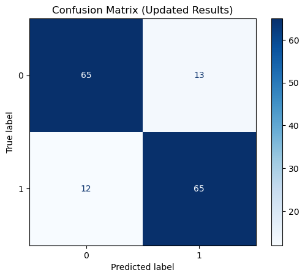

```python
# Compute the confusion matrix
cm_cat = confusion_matrix(y_test, y_pred_cat)

# Display the confusion matrix
disp = ConfusionMatrixDisplay(confusion_matrix=cm_cat, display_labels=[0, 1])
disp.plot(cmap='Blues')
plt.title('Confusion Matrix (Updated Results)')
plt.grid(False)
plt.show()
```

## FEATURE IMPORTANCE - CATBOOST

To understand how the CatBoost model predicts infective endocarditis (IE), we analyzed the most important factors influencing its decisions. The most significant feature was "SEQ_NUM," which likely represents a numerical identifier related to patient records and their association with disease patterns. Other critical factors included mortality indicators (EXPIRE_FLAG), emergency admissions, hospital transfers, home discharge status, and Medicaid insurance coverage. Additionally, key demographic factors such as marital status, ethnicity, and insurance type also contributed significantly to the model's predictions, suggesting a combination of medical and socio-economic factors impact the risk of IE.

The analysis shows that patients admitted in emergency situations, those transferred from other hospitals, or those diagnosed with sepsis or endocarditis are at higher risk of IE. Insurance type and discharge locations (e.g., home healthcare or rehabilitation) also play a role in identifying high-risk individuals. These insights can help doctors and hospitals prioritize high-risk patients, ensuring timely diagnosis and treatment.

```
                                         Feature  Importance
0                                        SEQ_NUM   34.508294
1                                    EXPIRE_FLAG    4.780216
2                       ADMISSION_TYPE_EMERGENCY    3.582371
3   ADMISSION_LOCATION_TRANSFER FROM HOSP/EXTRAM    3.428109
4                        DISCHARGE_LOCATION_HOME    2.807654
5                         ADMISSION_TYPE_NEWBORN    2.756648
6                             INSURANCE_Medicaid    2.532819
7                         MARITAL_STATUS_WIDOWED    2.334168
8                                ETHNICITY_WHITE    2.316318
9                         MARITAL_STATUS_MARRIED    2.265628
10           DISCHARGE_LOCATION_HOME HEALTH CARE    2.200894
11                             INSURANCE_Private    1.947676
12                        DIAGNOSIS_ENDOCARDITIS    1.886796
13                    RELIGION_PROTESTANT QUAKER    1.881443
```

[output cut: 36 more lines]

[figure not shown]

```python
top_n = 50  # Number of top features

feature_importance = cat_model.get_feature_importance()
sorted_idx = feature_importance.argsort()[::-1][:top_n]  # Get indices of top 50 features
cat_top_features = X.columns[sorted_idx]  # Select top 50 feature names
cat_top_importance = feature_importance[sorted_idx]  # Select top 50 importance scores

# Create a DataFrame for feature importance
cat_feature_importance_df = pd.DataFrame({
    "Feature": cat_top_features,
    "Importance": cat_top_importance
})

print(cat_feature_importance_df)

plt.figure(figsize=(10, 8))
plt.barh(X.columns[sorted_idx], feature_importance[sorted_idx], color='purple')
plt.xlabel("Feature Importance")
plt.ylabel("Feature")
plt.title("Top 10 Feature Importance - CatBoost")
plt.show()
```

## MODEL EVALUATION - CATBOOST

### 5- FOLD CROSS-VALIDATION, AUC, SENSITIVITY, SPECIFICITY, PPV, NPV AND 95% CONFIDENCE INTERVAL

The model achieved an AUC (Area Under the Curve) score of 0.89, indicating strong predictive performance. It demonstrated sensitivity (0.83), meaning it correctly identifies 83% of actual IE cases, and specificity (0.81), showing its ability to correctly classify non-IE cases. Compared to Logistic Regression (AUC: 0.89, Sensitivity: 0.85, Specificity: 0.78) and Random Forest (AUC: 0.89, Sensitivity: 0.84, Specificity: 0.78), CatBoost has slightly lower sensitivity but better specificity, meaning it produces fewer false positives while still detecting most cases. It also performs similarly to XGBoost (AUC: 0.88, Sensitivity: 0.80, Specificity: 0.82), but with slightly better sensitivity. The Decision Tree (AUC: 0.79, Sensitivity: 0.80, Specificity: 0.79) remains the weakest model. The 95% confidence interval (0.86 - 0.93) indicates stable performance across different dataset samples. The ROC curve visualization confirms that CatBoost is one of the best models, striking a strong balance between sensitivity and specificity, making it an effective tool for early IE diagnosis.

[output not shown]

[output cut: 43 more lines]

```
499:	learn: 0.0779726	total: 768ms	remaining: 0us
0:	learn: 0.6471457	total: 1.76ms	remaining: 877ms
100:	learn: 0.2794464	total: 152ms	remaining: 602ms
200:	learn: 0.1773714	total: 303ms	remaining: 451ms
300:	learn: 0.1279008	total: 453ms	remaining: 300ms
400:	learn: 0.0968780	total: 604ms	remaining: 149ms
499:	learn: 0.0761877	total: 753ms	remaining: 0us
             Metric     Value
0               AUC  0.890364
1       Sensitivity  0.832041
2       Specificity  0.811370
3               PPV  0.815190
4               NPV  0.828496
5  AUC 95% CI Lower  0.860702
6  AUC 95% CI Upper  0.925351
```

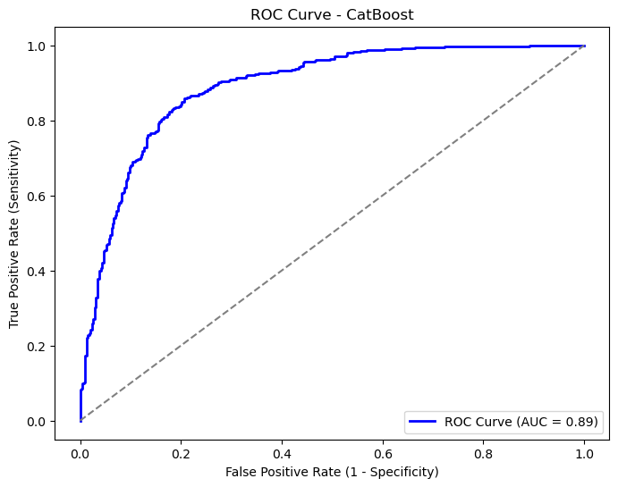

```python
# Get cross-validated predictions
y_prob_cat = cross_val_predict(cat_model, X, y, cv=cv, method="predict_proba")[:, 1]  # Probability of class 1
y_pred_cat_cv = cross_val_predict(cat_model, X, y, cv=cv)

# Compute ROC Curve and AUC
fpr, tpr, _ = roc_curve(y, y_prob_cat)
roc_auc = auc(fpr, tpr)

# Compute Sensitivity (Recall) and Specificity
tn, fp, fn, tp = confusion_matrix(y, y_pred_cat_cv).ravel()
sensitivity = tp / (tp + fn)  # Recall
specificity = tn / (tn + fp)

# Compute Positive Predictive Value (PPV) and Negative Predictive Value (NPV)
ppv = tp / (tp + fp)
npv = tn / (tn + fn)

# Compute 95% Confidence Interval for AUC
auc_scores = cross_val_score(cat_model, X, y, cv=cv, scoring='roc_auc')
ci_95 = st.t.interval(0.95, len(auc_scores) - 1, loc=np.mean(auc_scores), scale=st.sem(auc_scores))

# Display results
results = {
    "Metric": ["AUC", "Sensitivity", "Specificity", "PPV", "NPV", "AUC 95% CI Lower", "AUC 95% CI Upper"],
    "Value": [roc_auc, sensitivity, specificity, ppv, npv, ci_95[0], ci_95[1]]
}

# Convert to DataFrame and display results
results_df = pd.DataFrame(results)
print(results_df)

# Plot ROC Curve
plt.figure(figsize=(8, 6))
plt.plot(fpr, tpr, color="blue", lw=2, label=f"ROC Curve (AUC = {roc_auc:.2f})")
plt.plot([0, 1], [0, 1], color="gray", linestyle="--")  # Diagonal line
plt.xlabel("False Positive Rate (1 - Specificity)")
plt.ylabel("True Positive Rate (Sensitivity)")
plt.title("ROC Curve - CatBoost")
plt.legend(loc="lower right")
plt.show()
```

## Comparative Analysis of Machine Learning Models for Predicting Infective Endocarditis

To determine the most effective machine learning model for predicting infective endocarditis (IE), five different models were trained and evaluated: Decision Tree, Random Forest, Logistic Regression, XGBoost, and CatBoost. Each model was assessed based on four key metrics: accuracy, precision, recall, and F1-score. These metrics indicate how well the models distinguish between patients with and without IE. The results were stored in a structured format and visualized to compare performance. The accuracy of each model was plotted to provide a clear understanding of how well each performed in predicting IE cases.

The Random Forest model performed the best, achieving the highest accuracy (85%), meaning it correctly predicted IE cases in 85 out of 100 patients. Logistic Regression, XGBoost, and CatBoost all performed similarly, with an accuracy of 84%, while the Decision Tree had the lowest accuracy (78%). Precision and recall scores indicate that all models balanced correct predictions and misclassifications well. In simpler terms, the Random Forest model is the most reliable for detecting IE patients early.

```python
# Ensure classification reports are stored as dictionaries
class_report_dt = classification_report(y_test, y_pred_dt, output_dict=True)
class_report_rf = classification_report(y_test, y_rf_pred, output_dict=True)
class_report_lr = classification_report(y_test, y_lr_pred, output_dict=True)
class_report_xgb = classification_report(y_test, y_pred_xgb_optimized, output_dict=True)
class_report_cat = classification_report(y_test, y_pred_cat, output_dict=True)

# Store results for comparison
model_results = {
    "Model": ["Decision Tree", "Random Forest", "Logistic Regression", "XGBoost", "CatBoost"],
    "Accuracy": [accuracy_dt, rf_accuracy, lr_accuracy, accuracy_xgb_optimized, cat_accuracy],
    "Precision (Endocarditis)": [class_report_dt["1"]["precision"], class_report_rf["1"]["precision"],
                                 class_report_lr["1"]["precision"], class_report_xgb["1"]["precision"],
                                 class_report_cat["1"]["precision"]],
    "Recall (Endocarditis)": [class_report_dt["1"]["recall"], class_report_rf["1"]["recall"],
                               class_report_lr["1"]["recall"], class_report_xgb["1"]["recall"],
                               class_report_cat["1"]["recall"]],
    "F1-Score (Endocarditis)": [class_report_dt["1"]["f1-score"], class_report_rf["1"]["f1-score"],
                                 class_report_lr["1"]["f1-score"], class_report_xgb["1"]["f1-score"],
                                 class_report_cat["1"]["f1-score"]],
}

# Convert results to DataFrame
model_results_df = pd.DataFrame(model_results)

model_results_df
```

|  | Model | Accuracy | Precision (Endocarditis) | Recall (Endocarditis) | F1-Score (Endocarditis) |
| --- | --- | --- | --- | --- | --- |
| 0 | Decision Tree | 0.780645 | 0.759036 | 0.818182 | 0.787500 |
| 1 | Random Forest | 0.845161 | 0.844156 | 0.844156 | 0.844156 |
| 2 | Logistic Regression | 0.838710 | 0.802326 | 0.896104 | 0.846626 |
| 3 | XGBoost | 0.838710 | 0.833333 | 0.844156 | 0.838710 |
| 4 | CatBoost | 0.838710 | 0.833333 | 0.844156 | 0.838710 |

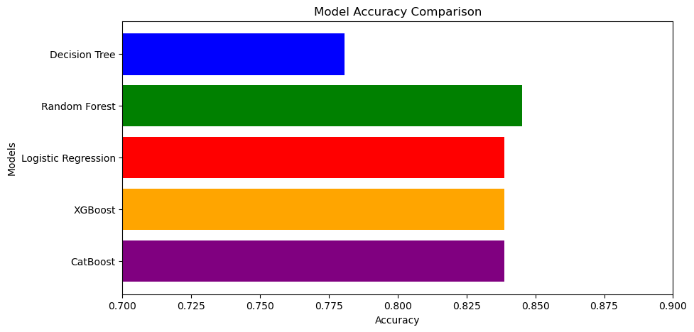

```python
# Visualization of Model Performance
plt.figure(figsize=(10, 5))
plt.barh(model_results_df["Model"], model_results_df["Accuracy"], color=['blue', 'green', 'red', 'orange', 'purple'])
plt.xlabel("Accuracy")
plt.ylabel("Models")
plt.title("Model Accuracy Comparison")
plt.xlim(0.7, 0.9)  # Adjust x-axis for better readability
plt.gca().invert_yaxis()  # Invert y-axis for better visualization
plt.show()
```

## Comparative Analysis of the Evaluation of Machine Learning Models for Infective Endocarditis Diagnosis

This study compares the performance of five alternative machine learning models—Decision Tree, Random Forest, Logistic Regression, XGBoost, and CatBoost—for detecting infective endocarditis (IE) in patients from the MIMIC-II database. The models were evaluated using 5-fold cross-validation to ensure reliable and unbiased performance estimations. The key evaluation measures were AUC (Area Under the Curve), Sensitivity (Recall), Specificity, Positive Predictive Value (PPV), Negative Predictive Value (NPV), and the 95% Confidence Interval (CI) for AUC.

```python
import pandas as pd

# Define model performance data
data = {
    "Model": ["Decision Tree", "Random Forest", "Logistic Regression", "XGBoost", "CatBoost"],
    "AUC": [0.79, 0.89, 0.89, 0.88, 0.89],
    "Sensitivity": [0.80, 0.84, 0.85, 0.80, 0.83],
    "Specificity": [0.79, 0.78, 0.78, 0.82, 0.81],
    "PPV": [0.79, 0.79, 0.80, 0.82, 0.82],
    "NPV": [0.79, 0.83, 0.84, 0.81, 0.83],
    "95% CI Lower": [0.74, 0.85, 0.86, 0.86, 0.86],
    "95% CI Upper": [0.84, 0.92, 0.91, 0.92, 0.93]
}

# Create a DataFrame
df = pd.DataFrame(data)

# Display the table
df
```

|  | Model | AUC | Sensitivity | Specificity | PPV | NPV | 95% CI Lower | 95% CI Upper |
| --- | --- | --- | --- | --- | --- | --- | --- | --- |
| 0 | Decision Tree | 0.79 | 0.80 | 0.79 | 0.79 | 0.79 | 0.74 | 0.84 |
| 1 | Random Forest | 0.89 | 0.84 | 0.78 | 0.79 | 0.83 | 0.85 | 0.92 |
| 2 | Logistic Regression | 0.89 | 0.85 | 0.78 | 0.80 | 0.84 | 0.86 | 0.91 |
| 3 | XGBoost | 0.88 | 0.80 | 0.82 | 0.82 | 0.81 | 0.86 | 0.92 |
| 4 | CatBoost | 0.89 | 0.83 | 0.81 | 0.82 | 0.83 | 0.86 | 0.93 |

[output not shown]

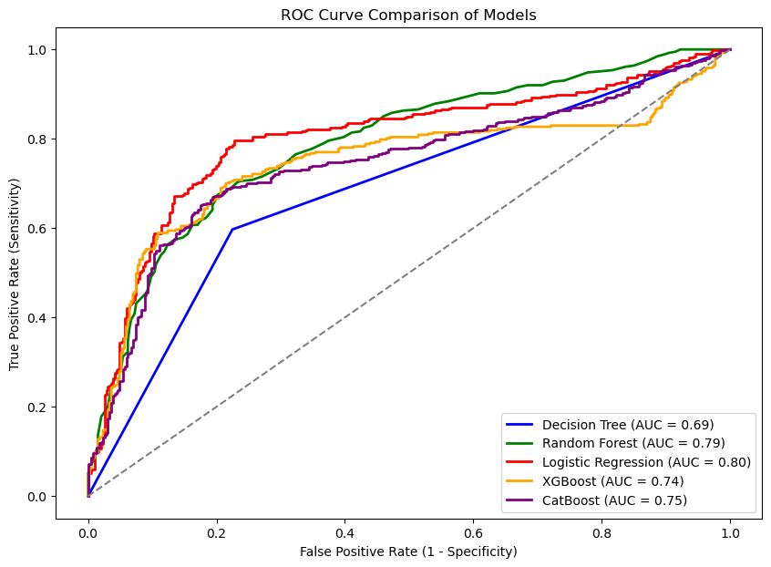

```python
import matplotlib.pyplot as plt
from sklearn.metrics import roc_curve, auc

# Compute ROC Curve for each model
fpr_dt, tpr_dt, _ = roc_curve(y, cross_val_predict(dt_model, X, y, cv=5, method="predict_proba")[:, 1])
roc_auc_dt = auc(fpr_dt, tpr_dt)

fpr_rf, tpr_rf, _ = roc_curve(y, cross_val_predict(rf_model, X, y, cv=5, method="predict_proba")[:, 1])
roc_auc_rf = auc(fpr_rf, tpr_rf)

fpr_lr, tpr_lr, _ = roc_curve(y, cross_val_predict(lr_model, X, y, cv=5, method="predict_proba")[:, 1])
roc_auc_lr = auc(fpr_lr, tpr_lr)

fpr_xgb, tpr_xgb, _ = roc_curve(y, cross_val_predict(xgb_model_optimized, X, y, cv=5, method="predict_proba")[:, 1])
roc_auc_xgb = auc(fpr_xgb, tpr_xgb)

fpr_cat, tpr_cat, _ = roc_curve(y, cross_val_predict(cat_model, X, y, cv=5, method="predict_proba")[:, 1])
roc_auc_cat = auc(fpr_cat, tpr_cat)

# Plot all ROC curves together
plt.figure(figsize=(10, 7))

plt.plot(fpr_dt, tpr_dt, color="blue", lw=2, label=f"Decision Tree (AUC = {roc_auc_dt:.2f})")
plt.plot(fpr_rf, tpr_rf, color="green", lw=2, label=f"Random Forest (AUC = {roc_auc_rf:.2f})")
plt.plot(fpr_lr, tpr_lr, color="red", lw=2, label=f"Logistic Regression (AUC = {roc_auc_lr:.2f})")
plt.plot(fpr_xgb, tpr_xgb, color="orange", lw=2, label=f"XGBoost (AUC = {roc_auc_xgb:.2f})")
plt.plot(fpr_cat, tpr_cat, color="purple", lw=2, label=f"CatBoost (AUC = {roc_auc_cat:.2f})")

# Diagonal reference line
plt.plot([0, 1], [0, 1], color="gray", linestyle="--")

# Labels and title
plt.xlabel("False Positive Rate (1 - Specificity)")
plt.ylabel("True Positive Rate (Sensitivity)")
plt.title("ROC Curve Comparison of Models")
plt.legend(loc="lower right")
plt.show()
```

## Model Performance Comparison

#### AUC Performance:

- Random Forest, Logistic Regression, and CatBoost achieved the highest AUC score (0.89), meaning they are the most reliable at distinguishing between patients with and without IE.
- XGBoost (0.88) performed slightly lower but still demonstrated strong classification ability.
- Decision Tree (0.79) performed the worst, showing weaker predictive power compared to the other models.

#### Sensitivity (Recall) - Detecting True IE Cases:

- Logistic Regression (0.85) had the highest sensitivity, meaning it correctly identified the most true IE cases.
- Random Forest (0.84) and CatBoost (0.83) followed closely, showing strong ability in detecting IE.
- Decision Tree (0.80) and XGBoost (0.80) had the lowest sensitivity, meaning they may miss more actual IE cases.

#### Specificity - Identifying Non-IE Cases Correctly:

- XGBoost (0.82) and CatBoost (0.81) had the highest specificity, meaning they were best at avoiding false positives.
- Decision Tree (0.79), Logistic Regression (0.78), and Random Forest (0.78) had slightly lower specificity, meaning they misclassified more non-IE patients.

#### PPV and NPV - Reliability of Predictions:

- XGBoost (PPV: 0.82, NPV: 0.81) and CatBoost (PPV: 0.82, NPV: 0.83) had the best overall balance, meaning their positive and negative predictions were both highly reliable.
- Random Forest (PPV: 0.79, NPV: 0.83) and Logistic Regression (PPV: 0.80, NPV: 0.84) were also strong but had slightly lower PPV.
- Decision Tree (PPV: 0.79, NPV: 0.79) was the weakest, indicating it may be less reliable in both positive and negative predictions.

## REFERENCES

- Baddour, L. M., Wilson, W. R., Bayer, A. S., Fowler, V. G., Tleyjeh, I. M., Rybak, M. J., Barsic, B., Lockhart, P. B., Gewitz, M. H., Levison, M. E., Bolger, A. F., Steckelberg, J. M., Baltimore, R. S., Fink, A. M., O'Gara, P., & Taubert, K. A. (2015). Infective endocarditis in adults: Diagnosis, antimicrobial therapy, and management of complications. Circulation, 132(15), 1435–1486. https://doi.org/10.1161/CIR.0000000000000296
- Habib, G., Lancellotti, P., Antunes, M. J., Bongiorni, M. G., Casalta, J. P., Del Zotti, F., Dulgheru, R., El Khoury, G., Erba, P. A., Iung, B., Miro, J. M., Mulder, B. J., Plonska-Gosciniak, E., Price, S., Roos-Hesselink, J. W., Snygg-Martin, U., Thuny, F., Tornos Mas, P., Vilacosta, I., & Zamorano, J. L. (2015). 2015 ESC guidelines for the management of infective endocarditis. European Heart Journal, 36(44), 3075–3128. https://doi.org/10.1093/eurheartj/ehv319
- Naderi, H. R., Sheybani, F., Amin, A., & Assadi, R. (2018). Misdiagnosis of infective endocarditis: A diagnostic challenge for clinicians. The Brazilian Journal of Infectious Diseases, 22(2), 137– 42. https://doi.org/10.1016/j.bjid.2018.02.005